# dataCovid : quelques éléments d’analyse

cb

22/05/2020

## 1 - les données

Elles proviennent de 8 vagues d’enquêtes réalisées par Ipsos pour le baromètre [DataCovid](https://datacovid.org/), de 5000 individus chacune de avril à juin 2020.

### importation et sélection des variables

```r
foo1<-as.data.frame(fread("~/covid/DataIpsos/Datacovid_BD_Vague_1.tsv")) %>% select(SERIAL,DEVICE,SEXE,AGE2,REG12,AGGLO5,EMP,PCSI,MAR,A0_0,A0_1,A0_2,A1,A2,A3_0,A3_1,B1Q,B2_0,B2_1,B2_2,B2_3,B2_4,B2_5,B2_6,B2_7,B2_8,C5_0,C5_1,C5_2,C5_3) %>% mutate(VAGUE=1)

foo2 <- as.data.frame(fread("~/covid/DataIpsos/Datacovid_BD_Vague_2.tsv")) %>% select(SERIAL,DEVICE,SEXE,AGE2,REG12,AGGLO5,EMP,PCSI,MAR,A0_0,A0_1,A0_2,A1,A2,A3_0,A3_1,B1Q,B2_0,B2_1,B2_2,B2_3,B2_4,B2_5,B2_6,B2_7,B2_8,C5_0,C5_1,C5_2,C5_3) %>%mutate(VAGUE=2)

foo3 <- as.data.frame(fread("~/covid/DataIpsos/Datacovid_BD_Vague_3.tsv")) %>% select(SERIAL,DEVICE,SEXE,AGE2,REG12,AGGLO5,EMP,PCSI,MAR,A0_0,A0_1,A0_2,A1,A2,A3_0,A3_1,B1Q,B2_0,B2_1,B2_2,B2_3,B2_4,B2_5,B2_6,B2_7,B2_8,C5_0,C5_1,C5_2,C5_3) %>%mutate(VAGUE=3)

foo4 <- as.data.frame(fread("~/covid/DataIpsos/Datacovid_BD_Vague_4.tsv")) %>% select(SERIAL,DEVICE,SEXE,AGE2,REG12,AGGLO5,EMP,PCSI,MAR,A0_0,A0_1,A0_2,A1,A2,A3_0,A3_1,B1Q,B2_0,B2_1,B2_2,B2_3,B2_4,B2_5,B2_6,B2_7,B2_8,C5_0,C5_1,C5_2,C5_3) %>%mutate(VAGUE=4)

foo5 <- as.data.frame(fread("~/covid/DataIpsos/Datacovid_BD_Vague_5.tsv"))%>% select(SERIAL,DEVICE,SEXE,AGE2,REG12,AGGLO5,EMP,PCSI,MAR,A0_0,A0_1,A0_2,A1,A2,A3_0,A3_1,B1Q,B2_0,B2_1,B2_2,B2_3,B2_4,B2_5,B2_6,B2_7,B2_8,C5_0,C5_1,C5_2,C5_3) %>%mutate(VAGUE=5)

foo6 <- as.data.frame(fread("~/covid/DataIpsos/Datacovid_BD_Vague_6.tsv")) %>% select(SERIAL,DEVICE,SEXE,AGE2,REG12,AGGLO5,EMP,PCSI,MAR,A0_0,A0_1,A0_2,A1,A2,A3_0,A3_1,B1Q,B2_0,B2_1,B2_2,B2_3,B2_4,B2_5,B2_6,B2_7,B2_8,C5_0,C5_1,C5_2,C5_3) %>%mutate(VAGUE=6)

foo7 <- as.data.frame(fread("~/covid/DataIpsos/Datacovid_BD_Vague_7.tsv")) %>% select(SERIAL,DEVICE,SEXE,AGE2,REG12,AGGLO5,EMP,PCSI,MAR,A0_0,A0_1,A0_2,A1,A2,A3_0,A3_1,B1Q,B2_0,B2_1,B2_2,B2_3,B2_4,B2_5,B2_6,B2_7,B2_8,C51,C52,C53,C54) %>%mutate(VAGUE=7) %>% rename(C5_0 = C51, C5_1 = C52, C5_2 = C53, C5_3 = C54)

foo8 <- as.data.frame(fread("~/covid/DataIpsos/Datacovid_BD_Vague_8.tsv")) %>% select(SERIAL,DEVICE,SEXE,AGE2,REG12,AGGLO5,EMP,PCSI,MAR,A0_0,A0_1,A0_2,A1,A2,A3_0,A3_1,B1Q,B2_0,B2_1,B2_2,B2_3,B2_4,B2_5,B2_6,B2_7,B2_8,C51,C52,C53,C54) %>%mutate(VAGUE=8) %>% rename(C5_0 = C51, C5_1 = C52, C5_2 = C53, C5_3 = C54)

df<-rbind(foo1,foo2,foo3,foo4,foo5,foo6,foo7,foo8)
df<-df %>% mutate(Gravity=B1Q)
```

### Quelques recodages

```r
#socio-demo
df$SEXE[df$SEXE==1]<-"Homme"
df$SEXE[df$SEXE==2]<-"Femme"
df$SEXE<-as.factor(df$SEXE)

df$AGE<-as.character(df$AGE2)
df$AGE[df$AGE2=="1"]<- "18-24"
df$AGE[df$AGE2=="2"]<- "25-29"
df$AGE[df$AGE2=="3"]<-"30-34"
df$AGE[df$AGE2=="4"]<-"35-39"
df$AGE[df$AGE2=="5"]<-"40-44"
df$AGE[df$AGE2=="6"]<-"45-49"
df$AGE[df$AGE2=="7"]<-"50-54"
df$AGE[df$AGE2=="8"]<-"55-59"
df$AGE[df$AGE2=="9"]<-"60-64"
df$AGE[df$AGE2=="10"]<-"65+"
df$AGE<-factor(df$AGE,ordered = TRUE,levels =c("18-24","25-29","30-34","35-39","40-44","45-49","50-54","55-59","60-64","65+"))

df$VAGUE2<-as.character(df$VAGUE)
df$VAGUE2[df$VAGUE=="1"]<- "7-14 avril"
df$VAGUE2[df$VAGUE=="2"]<- "15-22 avril"
df$VAGUE2[df$VAGUE=="3"]<-"23-30 avril"
df$VAGUE2[df$VAGUE=="4"]<-"1-8 mai"
df$VAGUE2[df$VAGUE=="5"]<-"9-16 mai"
df$VAGUE2[df$VAGUE=="6"]<-"17-24 mai"
df$VAGUE2[df$VAGUE=="7"]<-"24-31 mai"
df$VAGUE2[df$VAGUE=="8"]<-"01-6 juin"
df$VAGUE2<-factor(df$VAGUE2,ordered = TRUE,levels = c("7-14 avril", "15-22 avril", "23-30 avril", "1-8 mai","9-16 mai","17-24 mai","24-31 mai", "01-6 juin"))

df$AGGLO<-as.character(df$AGGLO5)
df$AGGLO[df$AGGLO=="1"]<- "Rural"
df$AGGLO[df$AGGLO=="2"]<- "Petites agglo"
df$AGGLO[df$AGGLO=="3"]<-"Moyenne agglo"
df$AGGLO[df$AGGLO=="4"]<-"Grandes agglo"
df$AGGLO[df$AGGLO=="5"]<-"Paris"
df$AGGLO<-factor(df$AGGLO,ordered = TRUE,levels = c( "Rural","Petites agglo","Moyenne agglo","Grandes agglo","Paris"))

df$REGION<-as.character(df$REG12)
df$REGION[df$REGION=="1"]<- "Ile-de-France"
df$REGION[df$REGION=="2"]<- "Centre-Val de Loire"
df$REGION[df$REGION=="3"]<-"Bourgogne-Franche-Comté"
df$REGION[df$REGION=="4"]<-"Normandie"
df$REGION[df$REGION=="5"]<-"Hauts-de-France"
df$REGION[df$REGION=="6"]<-"Grand-Est"
df$REGION[df$REGION=="7"]<-"Pays de la Loire"
df$REGION[df$REGION=="8"]<-"Bretagne"
df$REGION[df$REGION=="9"]<-"Nouvelle Aquitaine"
df$REGION[df$REGION=="10"]<-"Occitanie"
df$REGION[df$REGION=="11"]<-"Auvergne-Rhône-Alpes"
df$REGION[df$REGION=="12"]<-"PACA + Corse"
df$REGION<-factor(df$REGION,ordered = TRUE,levels = c("Ile-de-France","Centre-Val de Loire","Bourgogne-Franche-Comté","Normandie","Hauts-de-France","Grand-Est","Pays de la Loire", "Bretagne","Nouvelle Aquitaine","Occitanie","Auvergne-Rhône-Alpes","PACA + Corse"))

df$PCS<-as.character(df$PCSI)
df$PCS[df$PCS=="1"]<- "Agriculteurs exploitants"
df$PCS[df$PCS=="2"]<- "Professions Indépendantes"
df$PCS[df$PCS=="3"]<- "Cadres Supérieurs"
df$PCS[df$PCS=="4"]<- "Professions intermédiaires"
df$PCS[df$PCS=="5"]<- "Employés"
df$PCS[df$PCS=="6"]<- "Ouvriers"
df$PCS[df$PCS=="7"]<- "Retraités"
df$PCS[df$PCS=="8"]<- "Inactifs"
df$PCS<-factor(df$PCS,ordered = TRUE,levels = c("Agriculteurs exploitants","Professions Indépendantes","Cadres Supérieurs","Professions intermédiaires","Employés","Ouvriers", "Retraités","Inactifs"))

write_rds(df,"df.rds")
```

## 2 - Analyse de l’évolution des préoccupations

Question A0 : Parmi les sujets suivants, quelles sont les trois qui vous semblent les plus préoccupants aujourd’hui, pour vous personnellement ? (Colonne A0_0 : Préoccupation 1, A0_1 : Préocupation 2, A0_2 : Préoccupation 3). Valeurs possibles :

1 : L’épidémie de coronavirus 2 : Le pouvoir d’achat 3 : Le changement climatique 4 : Les inégalités sociales 5 : Le chômage 6 : Les déficits publics et de la dette de l’État 7 : L’éducation 8 : Le système de santé 9 : L’insécurité 10 : Le terrorisme

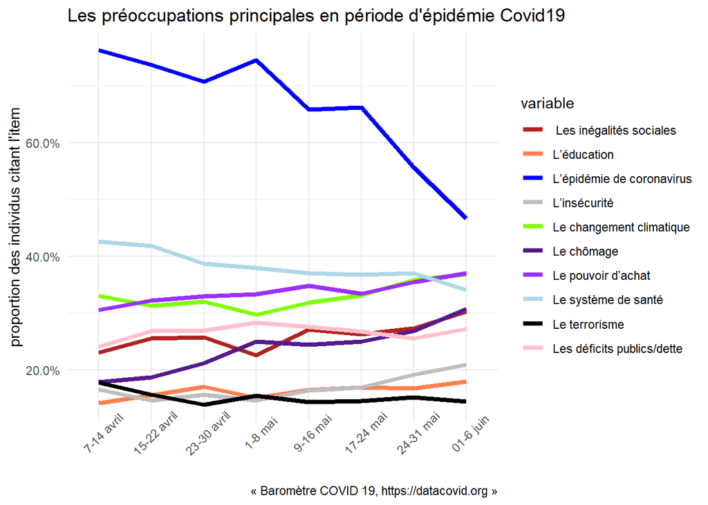

```r
#preoccupations : recodage des trois variables nominales en 10 variables binaires

df<-df %>% mutate(p_01=ifelse(A0_0==1 | A0_1==1 | A0_2==1,1,0))
df<-df %>% mutate(p_02=ifelse(A0_0==2 | A0_1==2 | A0_2==2,1,0))
df<-df %>% mutate(p_03=ifelse(A0_0==3 | A0_1==3 | A0_2==3,1,0))
df<-df %>% mutate(p_04=ifelse(A0_0==4 | A0_1==4 | A0_2==4,1,0))
df<-df %>% mutate(p_05=ifelse(A0_0==5 | A0_1==5 | A0_2==5,1,0))
df<-df %>% mutate(p_06=ifelse(A0_0==6 | A0_1==6 | A0_2==6,1,0))
df<-df %>% mutate(p_07=ifelse(A0_0==7 | A0_1==7 | A0_2==7,1,0))
df<-df %>% mutate(p_08=ifelse(A0_0==8 | A0_1==8 | A0_2==8,1,0))
df<-df %>% mutate(p_09=ifelse(A0_0==9 | A0_1==9 | A0_2==9,1,0))
df<-df %>% mutate(p_10=ifelse(A0_0==10 | A0_1==10 | A0_2==10,1,0))
##general
foo<-df  %>% select(VAGUE2,p_01,p_02,p_03,p_04,p_05,p_06,p_07,p_08,p_09,p_10)

foo<-melt(foo,id=c("VAGUE2"))%>% group_by(VAGUE2,variable) %>% summarise(frequence=mean(value))


foo$variable<-as.character(foo$variable)
foo$variable[foo$variable=="p_01"]<-"L’épidémie de coronavirus"
foo$variable[foo$variable=="p_02"]<-"Le pouvoir d’achat"
foo$variable[foo$variable=="p_03"]<-"Le changement climatique"
foo$variable[foo$variable=="p_04"]<-" Les inégalités sociales"
foo$variable[foo$variable=="p_05"]<-"Le chômage"
foo$variable[foo$variable=="p_06"]<-"Les déficits publics/dette"
foo$variable[foo$variable=="p_07"]<-"L’éducation"
foo$variable[foo$variable=="p_08"]<-"Le système de santé"
foo$variable[foo$variable=="p_09"]<-"L’insécurité"
foo$variable[foo$variable=="p_10"]<-"Le terrorisme"

foo$variable<-as.factor(foo$variable)

col=c("firebrick","coral","blue","grey","chartreuse","purple4","purple1","lightblue","black","pink")

ggplot(foo,aes(x=VAGUE2 ,y=frequence,group=variable))+geom_line(aes(color=variable),size=1.5)+
  theme_minimal()+
  labs(title = "Les préoccupations principales en période d'épidémie Covid19",x =NULL,y="proportion des individus citant l'item",caption = "« Baromètre COVID 19, https://datacovid.org »",ylab="vague d'enquête")+
  scale_color_manual(values=col)+
  theme(axis.text.x = element_text(angle=45))+
  scale_y_continuous(labels = scales::percent_format(accuracy=.1))
```

On peut éclater par sexe, mais finalement peu de différences générales sauf l’éductation et la sécrurité qui diffèrent sensiblement en niveau.

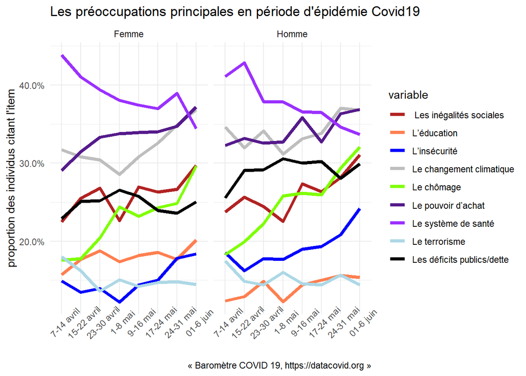

```r
#par categorie
foo<-df  %>% select(VAGUE2,SEXE,p_02,p_03,p_04,p_05,p_06,p_07,p_08,p_09,p_10)
foo<-melt(foo,id=c("VAGUE2","SEXE"))%>% group_by(VAGUE2,variable, SEXE) %>% summarise(frequence=mean(value))


foo$variable<-as.character(foo$variable)
foo$variable[foo$variable=="p_01"]<-"L’épidémie de coronavirus"
foo$variable[foo$variable=="p_02"]<-"Le pouvoir d’achat"
foo$variable[foo$variable=="p_03"]<-"Le changement climatique"
foo$variable[foo$variable=="p_04"]<-" Les inégalités sociales"
foo$variable[foo$variable=="p_05"]<-"Le chômage"
foo$variable[foo$variable=="p_06"]<-"Les déficits publics/dette"
foo$variable[foo$variable=="p_07"]<-"L’éducation"
foo$variable[foo$variable=="p_08"]<-"Le système de santé"
foo$variable[foo$variable=="p_09"]<-"L’insécurité"
foo$variable[foo$variable=="p_10"]<-"Le terrorisme"

foo$variable<-as.factor(foo$variable)

col=c("firebrick","coral","blue","grey","chartreuse","purple4","purple1","lightblue","black","pink")

ggplot(foo,aes(x=VAGUE2 ,y=frequence,group=variable))+geom_line(aes(color=variable),size=1.5)+
  theme_minimal()+
  labs(title = "Les préoccupations principales en période d'épidémie Covid19",x =NULL,y="proportion des individus citant l'item",caption = "« Baromètre COVID 19, https://datacovid.org »",ylab="vague d'enquête")+
  scale_color_manual(values=col)+
  theme(axis.text.x = element_text(angle=45))+
  scale_y_continuous(labels = scales::percent_format(accuracy=.1))+facet_wrap(vars(SEXE),ncol=2)
```

### corrélations entre les préoccupations

Examinons les corrélations entre ces éléments

Si elle sont toutes négatives, ou presque, c’est que compte tenu de la contrainte citer plus l’une décroit la probabilibilité de citation des autres.

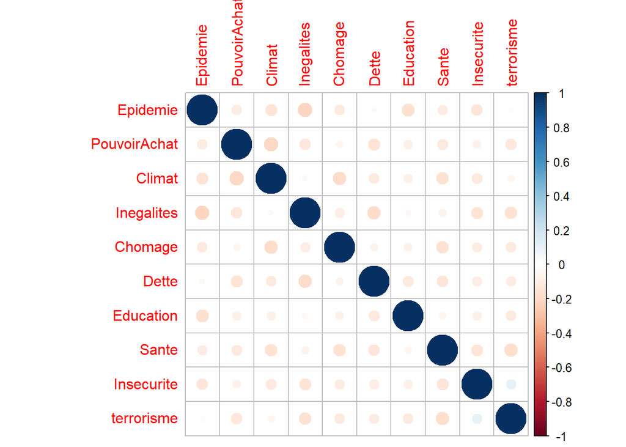

```r
#library(corrplot)


foo<-df  %>% select(p_01,p_02,p_03, p_04,p_05,p_06,p_07,p_08,p_09,p_10) %>% rename(Epidemie=p_01,PouvoirAchat=p_02,Climat=p_03,Inegalites=p_04,Chomage=p_05, Dette=p_06,Education=p_07,Sante=p_08,Insecurite=p_09, terrorisme=p_10)
r<-cor(foo)
corrplot(r)
```

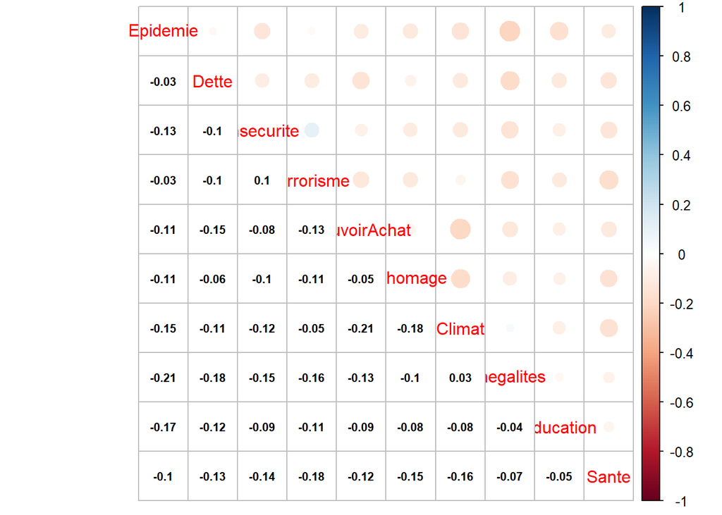

```r
corrplot.mixed(r, order = "hclust", addrect = 4, lower.col = "black", number.cex = .7)
```

Une autre manière est d’utiliser une méthode de clustering et de MDS sur une distance définie comme le nombre d’individus qui cite les items ensembles. C’ets pourquoi on utilise un indice de distance binaire de type jaccard.

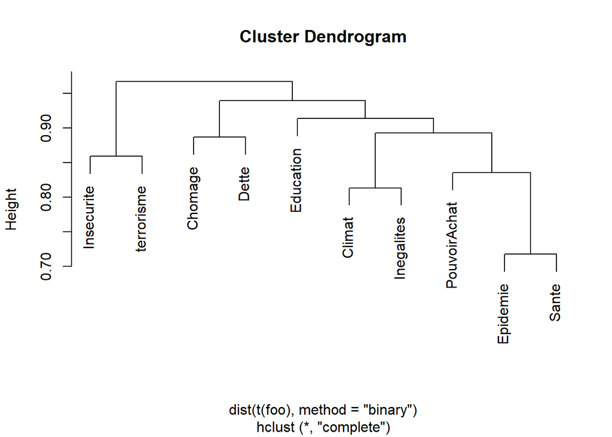

```r
hr <- hclust(dist(t(foo),method="binary"), method = "complete")
plot(hr)
```

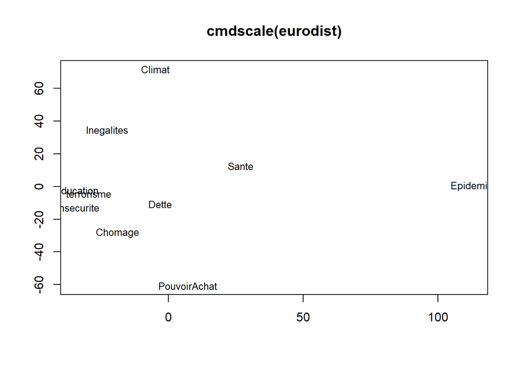

```r
loc <- cmdscale(dist(t(foo)), k=2,add=FALSE )
plot(loc[,1], -loc[,2], type="n", xlab="", ylab="", main="cmdscale(eurodist)")
text(loc[,1], -loc[,2], rownames(loc), cex=0.8)
```

## 3 - Perception de la gravité de l’épidémie

Une hypothèse simple est que la percepetion de la gravité est déterminante dans les comportements et notemment l’observance des gestes barrières. Mais avant de répondre à cette hypothèse , examinons de plus près les determinants socio démographiques

Q2.1. Sur une échelle de 0 à 10, comment évaluez-vous la gravité de l’épidémie de coronavirus aujourd’hui ? 0 voulant dire que selon vous elle n’est actuellement pas grave du tout. 10 voulant dire que selon vous elle est extrêmement grave. Les notes intermédiaires vous permettant de préciser votre jugement. I_**I**_I / 10

Examinons en détail l’age.

D’abord les faits :

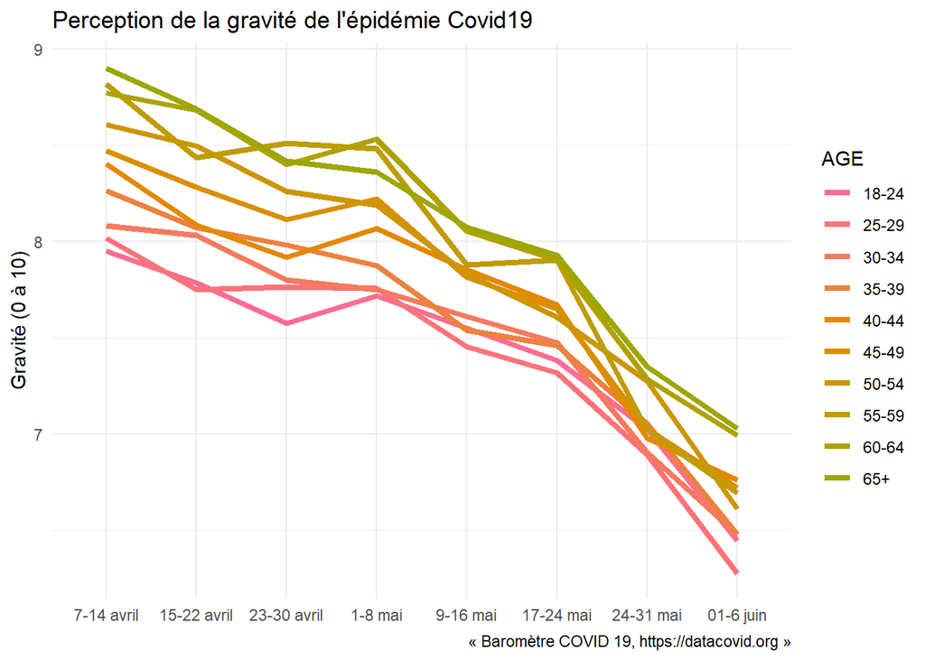

```r
foo<-df  %>% select(VAGUE2,B1Q,AGE)
foo<-melt(foo)

foo<-foo %>% group_by(AGE,VAGUE2) %>% summarise(Gravite=mean(value, na.rm = TRUE))

g0<-ggplot(foo,aes(x=VAGUE2 ,y=Gravite,group=AGE))+geom_line(aes(color=AGE),size=1.5)+  theme_minimal()+ labs(title = "Perception de la gravité de l'épidémie Covid19",x =NULL,y="Gravité (0 à 10)",caption = "« Baromètre COVID 19, https://datacovid.org »")+ scale_colour_hue(h = c(0, 90))
g0
```

La description graphique est cependant insuffisante pour apprécier les effets. Si l’évolution dans le temps est décroissante et que les différences d’âges sont systématiques on croit remarquer une variance moindre dans les dernières vague que dans les premières, dénotant une interaction : la décroissance de la perception de gravité est d’autant plus forte que les population sont agées. Un test est nécessaire, on emploie une ANOVA à deux facteurs plus une interaction.

```r
foo<-df  %>% select(VAGUE,B1Q,AGE2)
foo$AGE2<-5*foo$AGE2+17

m1<-lm(B1Q~AGE2*VAGUE,data=foo)
anova(m1)
```

```
## Analysis of Variance Table
##
## Response: B1Q
##               Df Sum Sq Mean Sq  F value    Pr(>F)
## AGE2           1   2366  2366.4  656.933 < 2.2e-16 ***
## VAGUE          1  12069 12069.4 3350.576 < 2.2e-16 ***
## AGE2:VAGUE     1    133   132.9   36.903 1.253e-09 ***
## Residuals  39997 144077     3.6
## ---
## Signif. codes:  0 '***' 0.001 '**' 0.01 '*' 0.05 '.' 0.1 ' ' 1
```

```r
summ(m1)
```

| Observations | 40001 |
| --- | --- |
| Dependent variable | B1Q |
| Type | OLS linear regression |

| F(3,39997) | 1348.14 |
| --- | --- |
| R² | 0.09 |
| Adj. R² | 0.09 |

|  | Est. | S.E. | t val. | p |
| --- | --- | --- | --- | --- |
| (Intercept) | 7.73 | 0.07 | 112.52 | 0.00 |
| AGE2 | 0.02 | 0.00 | 17.51 | 0.00 |
| VAGUE | -0.16 | 0.01 | -11.61 | 0.00 |
| AGE2:VAGUE | -0.00 | 0.00 | -6.07 | 0.00 |

Standard errors: OLS

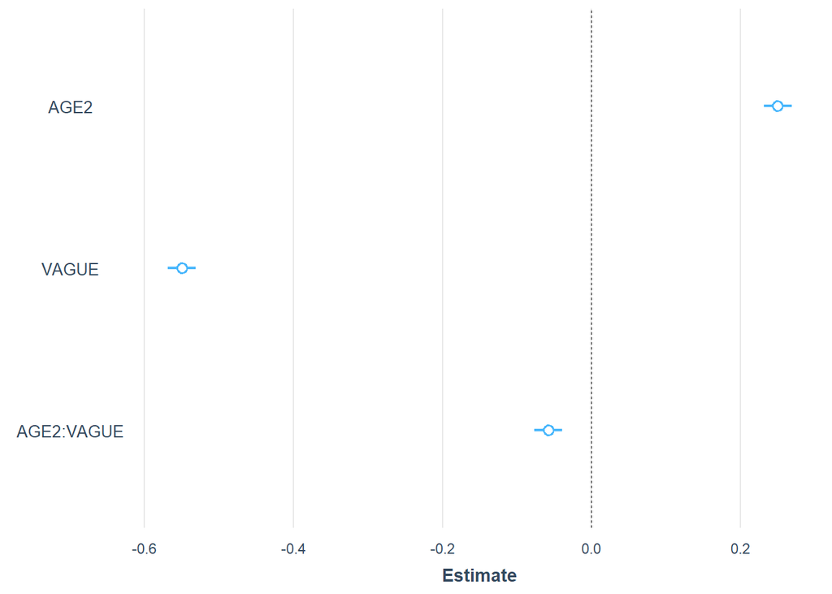

```r
plot_summs(m1, scale = TRUE)
```

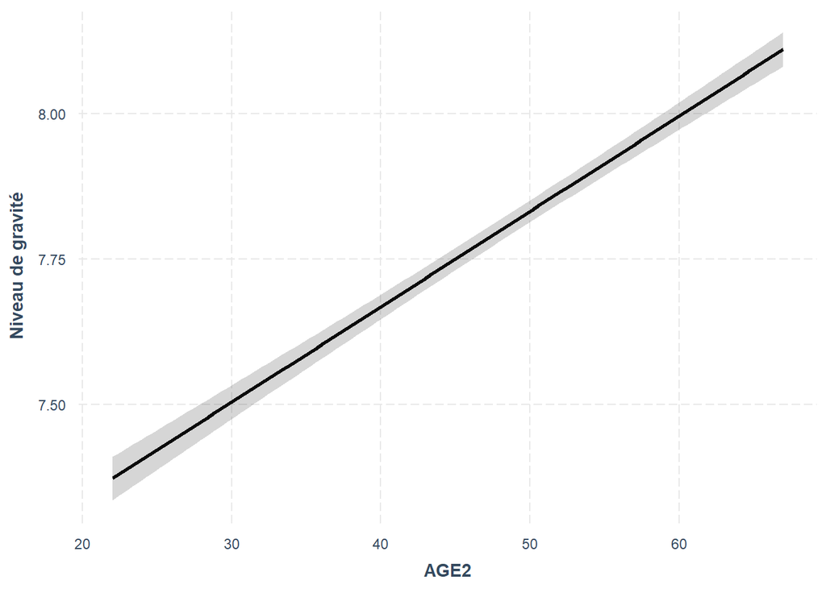

```r
effect_plot(m1, pred = AGE2, interval = TRUE, plot.points = FALSE, y.label = "Niveau de gravité")
```

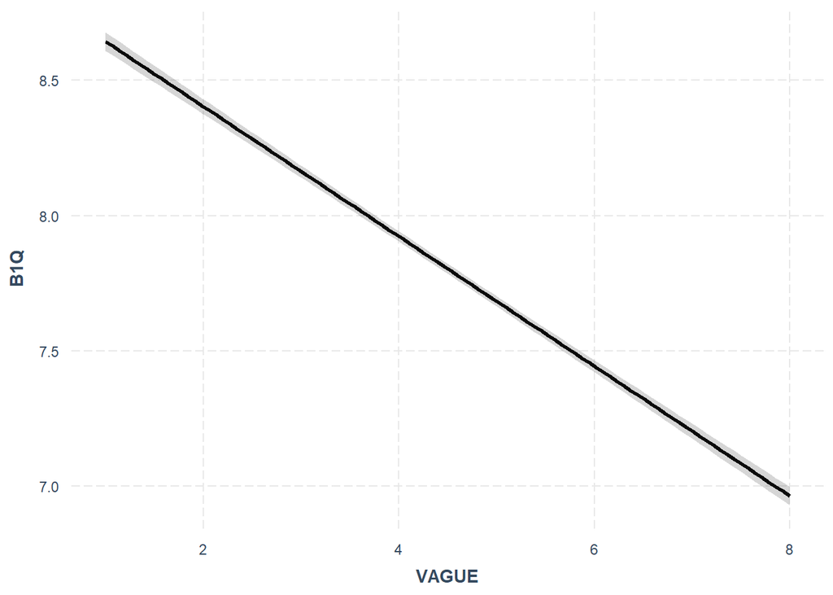

```r
effect_plot(m1, pred = VAGUE, interval = TRUE, plot.points = FALSE)
```

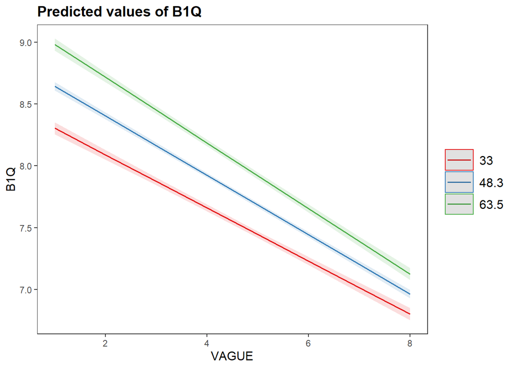

```r
plot_model(m1, type = "pred", terms = c("VAGUE", "AGE2"))+theme_apa()
```

Comme l’effet du temps n’est manifestement pas linéraire et que ce sont des enquêtes distinctes, on considèrera plutôt la variable comme qualitative et non ordonnées.

```r
foo<-df  %>% select(VAGUE2,B1Q,AGGLO)
foo$VAGUE2<-factor(foo$VAGUE2, ordered = FALSE ) #beaucause before ordered
foo$AGGLO<-factor(foo$AGGLO, ordered = FALSE )


m1<-lm(B1Q~AGGLO+VAGUE2,data=foo)
anova(m1)
```

```
## Analysis of Variance Table
##
## Response: B1Q
##              Df Sum Sq Mean Sq  F value Pr(>F)
## AGGLO         4     39    9.79   2.6883 0.0295 *
## VAGUE2        7  13035 1862.16 511.5433 <2e-16 ***
## Residuals 39989 145571    3.64
## ---
## Signif. codes:  0 '***' 0.001 '**' 0.01 '*' 0.05 '.' 0.1 ' ' 1
```

```r
summ(m1)
```

| Observations | 40001 |
| --- | --- |
| Dependent variable | B1Q |
| Type | OLS linear regression |

| F(11,39989) | 326.51 |
| --- | --- |
| R² | 0.08 |
| Adj. R² | 0.08 |

|  | Est. | S.E. | t val. | p |
| --- | --- | --- | --- | --- |
| (Intercept) | 8.55 | 0.03 | 260.55 | 0.00 |
| AGGLOPetites agglo | -0.05 | 0.03 | -1.62 | 0.11 |
| AGGLOMoyenne agglo | -0.03 | 0.03 | -1.03 | 0.30 |
| AGGLOGrandes agglo | -0.08 | 0.03 | -2.97 | 0.00 |
| AGGLOParis | -0.06 | 0.03 | -1.81 | 0.07 |
| VAGUE215-22 avril | -0.19 | 0.04 | -5.04 | 0.00 |
| VAGUE223-30 avril | -0.38 | 0.04 | -9.92 | 0.00 |
| VAGUE21-8 mai | -0.34 | 0.04 | -8.93 | 0.00 |
| VAGUE29-16 mai | -0.67 | 0.04 | -17.61 | 0.00 |
| VAGUE217-24 mai | -0.82 | 0.04 | -21.59 | 0.00 |
| VAGUE224-31 mai | -1.37 | 0.04 | -35.99 | 0.00 |
| VAGUE201-6 juin | -1.78 | 0.04 | -46.55 | 0.00 |

Standard errors: OLS

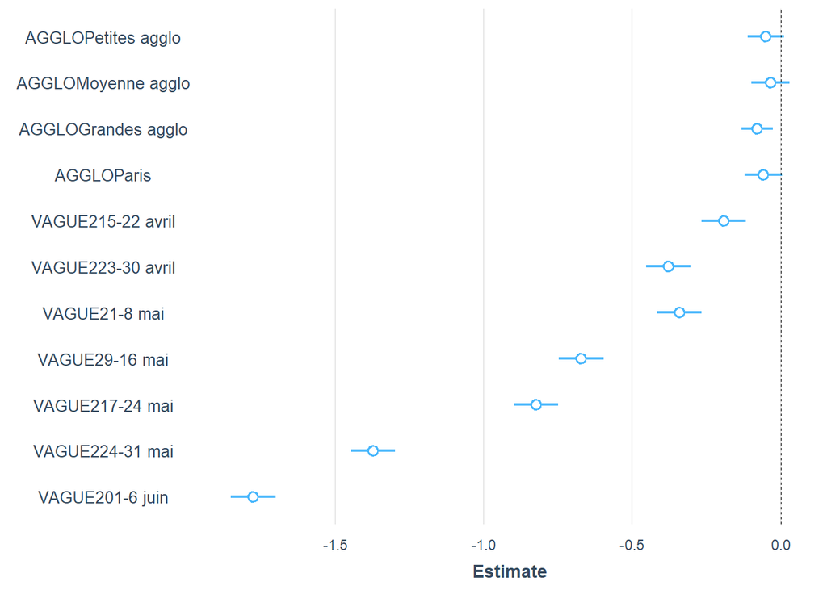

```r
plot_summs(m1, scale = TRUE)
```

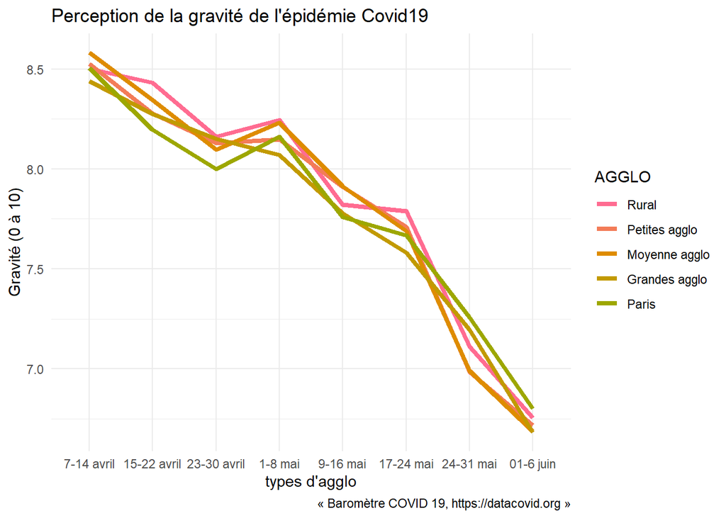

```r
foo<-melt(foo)%>% group_by(VAGUE2,AGGLO) %>% summarise(Gravite=mean(value))

g1<-ggplot(foo,aes(x=VAGUE2,y=Gravite,group=AGGLO))+geom_line(aes(color=AGGLO),size=1.5)+  theme_minimal()+  labs(title = "Perception de la gravité de l'épidémie Covid19",x ="types d'agglo",y="Gravité (0 à 10)",caption = "« Baromètre COVID 19, https://datacovid.org »")+ scale_colour_hue(h = c(0, 90))
g1
```

```r
foo<-df  %>% select(VAGUE2,B1Q,SEXE)
foo$VAGUE2<-factor(foo$VAGUE2, ordered = FALSE ) #beaucause before ordered
foo$SEXE<-factor(foo$SEXE, ordered = FALSE )

m1<-lm(B1Q~SEXE*VAGUE2,data=foo)
anova(m1)
```

```
## Analysis of Variance Table
##
## Response: B1Q
##                Df Sum Sq Mean Sq  F value Pr(>F)
## SEXE            1   1428 1427.82 396.0844 <2e-16 ***
## VAGUE2          7  13052 1864.52 517.2292 <2e-16 ***
## SEXE:VAGUE2     7     27    3.84   1.0665 0.3821
## Residuals   39985 144139    3.60
## ---
## Signif. codes:  0 '***' 0.001 '**' 0.01 '*' 0.05 '.' 0.1 ' ' 1
```

```r
summ(m1)
```

| Observations | 40001 |
| --- | --- |
| Dependent variable | B1Q |
| Type | OLS linear regression |

| F(15,39985) | 268.28 |
| --- | --- |
| R² | 0.09 |
| Adj. R² | 0.09 |

|  | Est. | S.E. | t val. | p |
| --- | --- | --- | --- | --- |
| (Intercept) | 8.67 | 0.04 | 236.76 | 0.00 |
| SEXEHomme | -0.38 | 0.05 | -7.00 | 0.00 |
| VAGUE215-22 avril | -0.22 | 0.05 | -4.37 | 0.00 |
| VAGUE223-30 avril | -0.40 | 0.05 | -7.85 | 0.00 |
| VAGUE21-8 mai | -0.38 | 0.05 | -7.43 | 0.00 |
| VAGUE29-16 mai | -0.65 | 0.05 | -12.62 | 0.00 |
| VAGUE217-24 mai | -0.82 | 0.05 | -15.93 | 0.00 |
| VAGUE224-31 mai | -1.36 | 0.05 | -26.42 | 0.00 |
| VAGUE201-6 juin | -1.75 | 0.05 | -34.12 | 0.00 |
| SEXEHomme:VAGUE215-22 avril | 0.05 | 0.08 | 0.69 | 0.49 |
| SEXEHomme:VAGUE223-30 avril | 0.04 | 0.08 | 0.50 | 0.62 |
| SEXEHomme:VAGUE21-8 mai | 0.07 | 0.08 | 0.98 | 0.33 |
| SEXEHomme:VAGUE29-16 mai | -0.08 | 0.08 | -1.03 | 0.30 |
| SEXEHomme:VAGUE217-24 mai | -0.02 | 0.08 | -0.30 | 0.77 |
| SEXEHomme:VAGUE224-31 mai | -0.04 | 0.08 | -0.54 | 0.59 |
| SEXEHomme:VAGUE201-6 juin | -0.06 | 0.08 | -0.81 | 0.42 |

Standard errors: OLS

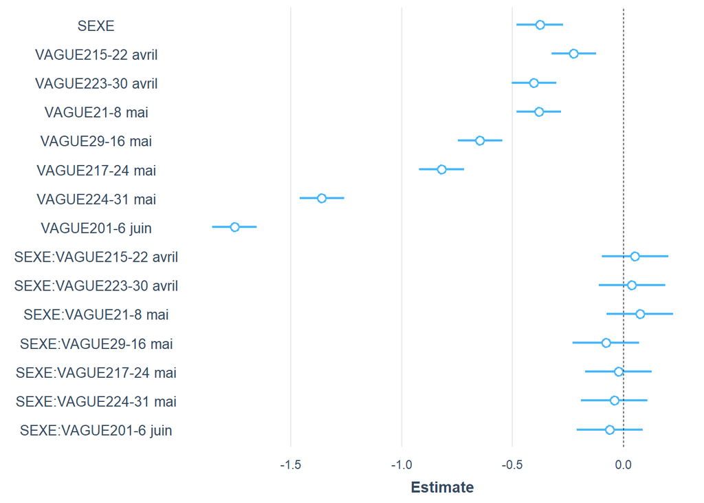

```r
plot_summs(m1, scale = TRUE)
```

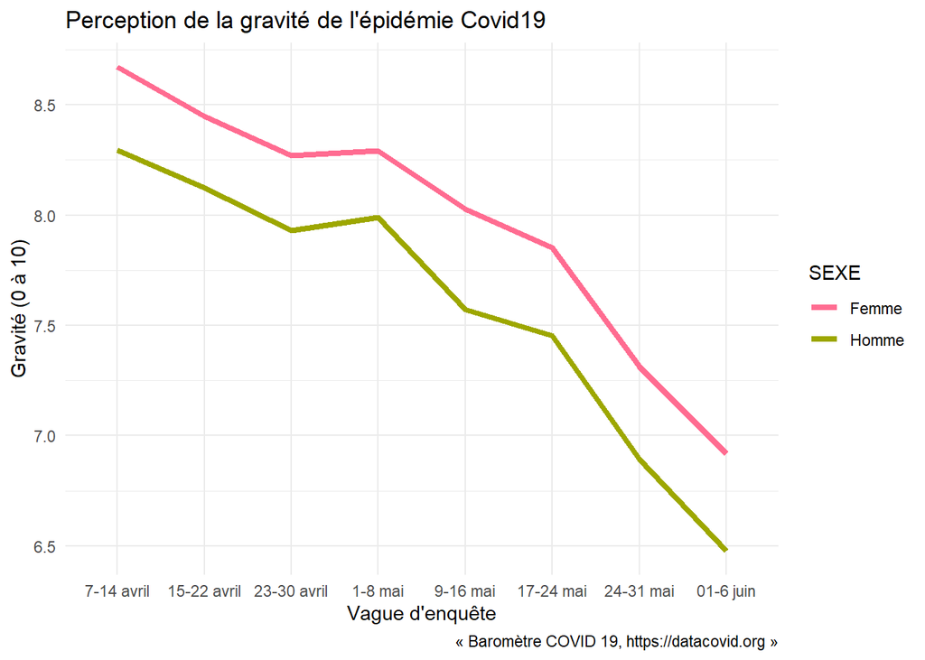

```r
foo<-melt(foo)%>% group_by(VAGUE2,SEXE) %>% summarise(Gravite=mean(value))

ggplot(foo,aes(x=VAGUE2 ,y=Gravite,group=SEXE))+geom_line(aes(color=SEXE),size=1.5)+  theme_minimal()+  labs(title = "Perception de la gravité de l'épidémie Covid19",x ="Vague d'enquête",y="Gravité (0 à 10)",caption = "« Baromètre COVID 19, https://datacovid.org »")+ scale_colour_hue(h = c(0, 90))
```

```r
foo<-df  %>% select(VAGUE2,B1Q,PCS)
foo$VAGUE2<-factor(foo$VAGUE2, ordered = FALSE ) #beaucause before ordered
foo$PCS<-factor(foo$PCS, ordered = FALSE )

m1<-lm(B1Q~PCS+VAGUE2,data=foo)
anova(m1)
```

```
## Analysis of Variance Table
##
## Response: B1Q
##              Df Sum Sq Mean Sq F value    Pr(>F)
## PCS           7   1957  279.57   77.86 < 2.2e-16 ***
## VAGUE2        7  13111 1873.05  521.64 < 2.2e-16 ***
## Residuals 39986 143577    3.59
## ---
## Signif. codes:  0 '***' 0.001 '**' 0.01 '*' 0.05 '.' 0.1 ' ' 1
```

```r
summ(m1)
```

| Observations | 40001 |
| --- | --- |
| Dependent variable | B1Q |
| Type | OLS linear regression |

| F(14,39986) | 299.75 |
| --- | --- |
| R² | 0.09 |
| Adj. R² | 0.09 |

|  | Est. | S.E. | t val. | p |
| --- | --- | --- | --- | --- |
| (Intercept) | 8.00 | 0.14 | 58.07 | 0.00 |
| PCSProfessions Indépendantes | 0.10 | 0.14 | 0.68 | 0.50 |
| PCSCadres Supérieurs | 0.15 | 0.14 | 1.08 | 0.28 |
| PCSProfessions intermédiaires | 0.36 | 0.14 | 2.62 | 0.01 |
| PCSEmployés | 0.55 | 0.14 | 4.02 | 0.00 |
| PCSOuvriers | 0.40 | 0.14 | 2.85 | 0.00 |
| PCSRetraités | 0.79 | 0.14 | 5.81 | 0.00 |
| PCSInactifs | 0.41 | 0.14 | 2.99 | 0.00 |
| VAGUE215-22 avril | -0.19 | 0.04 | -4.93 | 0.00 |
| VAGUE223-30 avril | -0.38 | 0.04 | -9.99 | 0.00 |
| VAGUE21-8 mai | -0.35 | 0.04 | -9.15 | 0.00 |
| VAGUE29-16 mai | -0.68 | 0.04 | -17.83 | 0.00 |
| VAGUE217-24 mai | -0.82 | 0.04 | -21.61 | 0.00 |
| VAGUE224-31 mai | -1.38 | 0.04 | -36.40 | 0.00 |
| VAGUE201-6 juin | -1.78 | 0.04 | -46.96 | 0.00 |

Standard errors: OLS

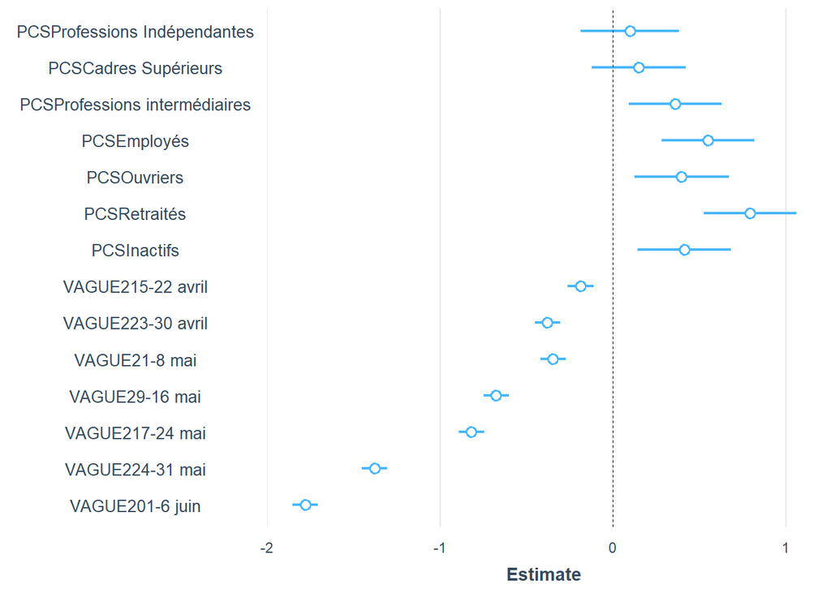

```r
plot_summs(m1, scale = TRUE)
```

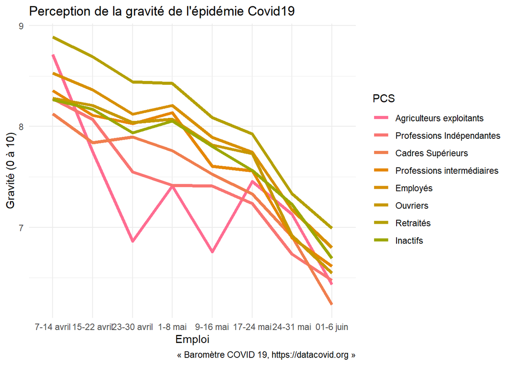

```r
foo<-melt(foo)%>% group_by(VAGUE2,PCS) %>% summarise(Gravite=mean(value))

g3<-ggplot(foo,aes(x=VAGUE2 ,y=Gravite,group=PCS))+geom_line(aes(color=PCS),size=1.5)+  theme_minimal()+  labs(title = "Perception de la gravité de l'épidémie Covid19",x ="Emploi",y="Gravité (0 à 10)",caption = "« Baromètre COVID 19, https://datacovid.org »")+ scale_colour_hue(h = c(0, 90))
g3
```

```r
foo<-df  %>% select(VAGUE2,B1Q,REGION)
foo$VAGUE2<-factor(foo$VAGUE2, ordered = FALSE ) #beaucause before ordered
foo$REGION<-factor(foo$REGION, ordered = FALSE )

m1<-lm(B1Q~REGION+VAGUE2,data=foo)
anova(m1)
```

```
## Analysis of Variance Table
##
## Response: B1Q
##              Df Sum Sq Mean Sq  F value    Pr(>F)
## REGION       11    283   25.73   7.0792 3.916e-12 ***
## VAGUE2        7  13049 1864.07 512.8863 < 2.2e-16 ***
## Residuals 39982 145314    3.63
## ---
## Signif. codes:  0 '***' 0.001 '**' 0.01 '*' 0.05 '.' 0.1 ' ' 1
```

```r
summ(m1)
```

| Observations | 40001 |
| --- | --- |
| Dependent variable | B1Q |
| Type | OLS linear regression |

| F(18,39982) | 203.78 |
| --- | --- |
| R² | 0.08 |
| Adj. R² | 0.08 |

|  | Est. | S.E. | t val. | p |
| --- | --- | --- | --- | --- |
| (Intercept) | 8.52 | 0.03 | 252.26 | 0.00 |
| REGIONCentre-Val de Loire | 0.05 | 0.05 | 0.91 | 0.36 |
| REGIONBourgogne-Franche-Comté | 0.00 | 0.05 | 0.07 | 0.94 |
| REGIONNormandie | -0.03 | 0.05 | -0.63 | 0.53 |
| REGIONHauts-de-France | 0.15 | 0.04 | 3.95 | 0.00 |
| REGIONGrand-Est | 0.02 | 0.04 | 0.46 | 0.64 |
| REGIONPays de la Loire | -0.08 | 0.04 | -1.79 | 0.07 |
| REGIONBretagne | -0.02 | 0.05 | -0.36 | 0.72 |
| REGIONNouvelle Aquitaine | -0.01 | 0.04 | -0.28 | 0.78 |
| REGIONOccitanie | -0.02 | 0.04 | -0.52 | 0.60 |
| REGIONAuvergne-Rhône-Alpes | -0.15 | 0.04 | -4.29 | 0.00 |
| REGIONPACA + Corse | -0.17 | 0.04 | -4.15 | 0.00 |
| VAGUE215-22 avril | -0.19 | 0.04 | -5.01 | 0.00 |
| VAGUE223-30 avril | -0.38 | 0.04 | -9.88 | 0.00 |
| VAGUE21-8 mai | -0.34 | 0.04 | -8.84 | 0.00 |
| VAGUE29-16 mai | -0.67 | 0.04 | -17.58 | 0.00 |
| VAGUE217-24 mai | -0.82 | 0.04 | -21.58 | 0.00 |
| VAGUE224-31 mai | -1.37 | 0.04 | -35.97 | 0.00 |
| VAGUE201-6 juin | -1.78 | 0.04 | -46.58 | 0.00 |

Standard errors: OLS

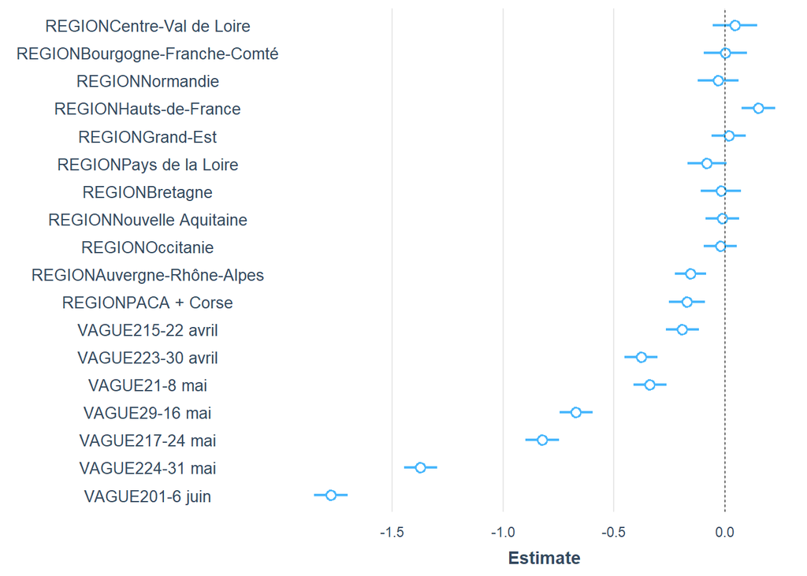

```r
plot_summs(m1, scale = TRUE)
```

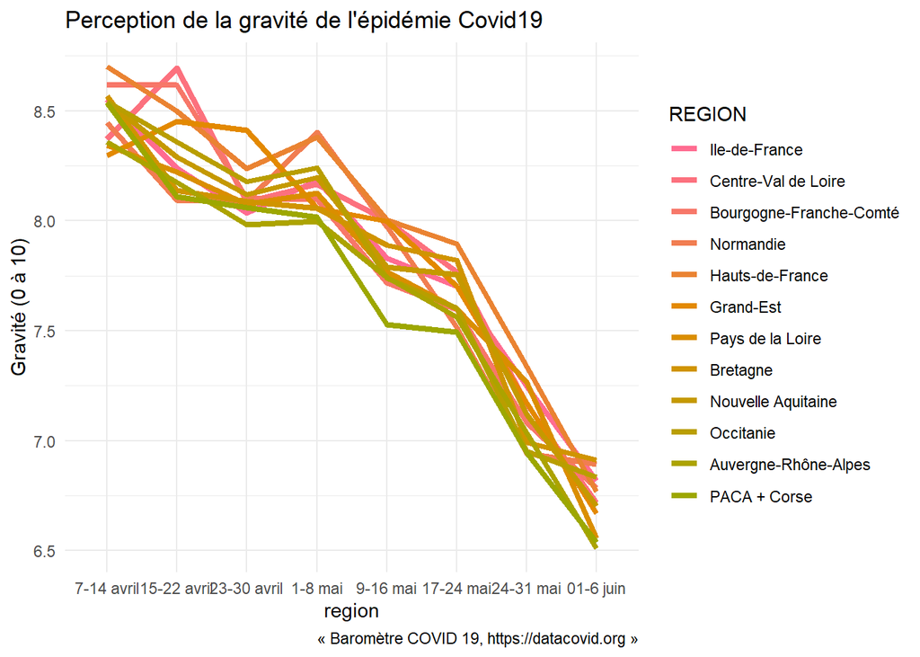

```r
foo<-melt(foo)%>% group_by(VAGUE2,REGION) %>% summarise(Gravite=mean(value))

g3<-ggplot(foo,aes(x=VAGUE2 ,y=Gravite,group=REGION))+geom_line(aes(color=REGION),size=1.5)+  theme_minimal()+  labs(title = "Perception de la gravité de l'épidémie Covid19",x ="region",y="Gravité (0 à 10)",caption = "« Baromètre COVID 19, https://datacovid.org »")+ scale_colour_hue(h = c(0, 90))
g3
```

## 4 - Modèles de régression

Pour les résultats on utilise les ressources de https://cran.r-project.org/web/packages/jtools/vignettes/summ.html

```r
foo<-df  %>% select(VAGUE2,B1Q,PCS,SEXE,AGE,AGGLO, REGION)
m1<-lm(B1Q~AGE+SEXE+VAGUE2+PCS+AGGLO+REGION,data=foo)
anova(m1)
```

```
## Analysis of Variance Table
##
## Response: B1Q
##              Df Sum Sq Mean Sq  F value    Pr(>F)
## AGE           9   2418  268.62  76.5480 < 2.2e-16 ***
## SEXE          1   2007 2006.78 571.8645 < 2.2e-16 ***
## VAGUE2        7  13186 1883.75 536.8071 < 2.2e-16 ***
## PCS           7    484   69.09  19.6878 < 2.2e-16 ***
## AGGLO         4     17    4.30   1.2254    0.2976
## REGION       11    303   27.59   7.8619 8.441e-14 ***
## Residuals 39961 140230    3.51
## ---
## Signif. codes:  0 '***' 0.001 '**' 0.01 '*' 0.05 '.' 0.1 ' ' 1
```

```r
summary(m1)
```

```
##
## Call:
## lm(formula = B1Q ~ AGE + SEXE + VAGUE2 + PCS + AGGLO + REGION,
##     data = foo)
##
## Residuals:
##     Min      1Q  Median      3Q     Max
## -9.0814 -0.8837  0.2920  1.3252  4.3659
##
## Coefficients:
##              Estimate Std. Error t value Pr(>|t|)
## (Intercept)  7.834104   0.023794 329.245  < 2e-16 ***
## AGE.L        0.796416   0.044963  17.713  < 2e-16 ***
## AGE.Q       -0.032390   0.040203  -0.806  0.42043
## AGE.C       -0.090824   0.033266  -2.730  0.00633 **
## AGE^4        0.019074   0.031695   0.602  0.54731
## AGE^5       -0.029994   0.033040  -0.908  0.36399
## AGE^6       -0.001091   0.033075  -0.033  0.97369
## AGE^7       -0.012569   0.032450  -0.387  0.69850
## AGE^8        0.023294   0.031972   0.729  0.46626
## AGE^9       -0.011254   0.031399  -0.358  0.72003
## SEXEHomme   -0.437939   0.019646 -22.292  < 2e-16 ***
## VAGUE2.L    -1.555192   0.026536 -58.608  < 2e-16 ***
## VAGUE2.Q    -0.404344   0.026505 -15.256  < 2e-16 ***
## VAGUE2.C    -0.155926   0.026504  -5.883 4.06e-09 ***
## VAGUE2^4     0.082120   0.026518   3.097  0.00196 **
## VAGUE2^5     0.047705   0.026504   1.800  0.07187 .
## VAGUE2^6     0.037061   0.026513   1.398  0.16217
## VAGUE2^7     0.147802   0.026503   5.577 2.47e-08 ***
## PCS.L        0.412325   0.078610   5.245 1.57e-07 ***
## PCS.Q       -0.151577   0.076488  -1.982  0.04752 *
## PCS.C       -0.125559   0.065374  -1.921  0.05479 .
## PCS^4        0.055884   0.054315   1.029  0.30354
## PCS^5        0.047884   0.042645   1.123  0.26150
## PCS^6       -0.023484   0.034799  -0.675  0.49978
## PCS^7       -0.029889   0.026121  -1.144  0.25252
## AGGLO.L     -0.097318   0.042291  -2.301  0.02139 *
## AGGLO.Q     -0.066280   0.038765  -1.710  0.08731 .
## AGGLO.C     -0.071268   0.029232  -2.438  0.01477 *
## AGGLO^4     -0.012723   0.024138  -0.527  0.59814
## REGION.L    -0.255419   0.043034  -5.935 2.96e-09 ***
## REGION.Q    -0.037543   0.042637  -0.881  0.37858
## REGION.C    -0.093282   0.042537  -2.193  0.02832 *
## REGION^4     0.043760   0.040317   1.085  0.27775
## REGION^5    -0.104325   0.038395  -2.717  0.00659 **
## REGION^6     0.046999   0.037343   1.259  0.20818
## REGION^7     0.104358   0.037102   2.813  0.00491 **
## REGION^8    -0.035253   0.036817  -0.957  0.33832
## REGION^9    -0.065787   0.036425  -1.806  0.07091 .
## REGION^10    0.074950   0.035882   2.089  0.03673 *
## REGION^11   -0.018336   0.035181  -0.521  0.60223
## ---
## Signif. codes:  0 '***' 0.001 '**' 0.01 '*' 0.05 '.' 0.1 ' ' 1
##
## Residual standard error: 1.873 on 39961 degrees of freedom
## Multiple R-squared:  0.1161, Adjusted R-squared:  0.1152
## F-statistic: 134.6 on 39 and 39961 DF,  p-value: < 2.2e-16
```

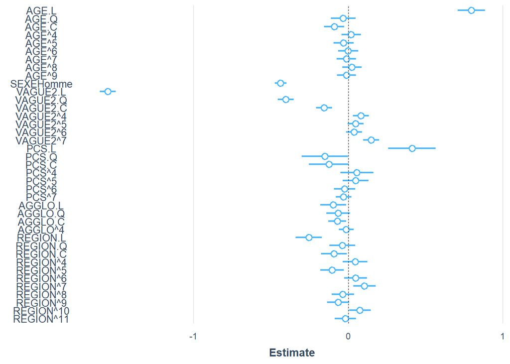

```r
library(ggeffects)
library(jtools)
plot_summs(m1, scale = FALSE)
```

```r
library(kableExtra)
summ(m1)
```

| Observations | 40001 |
| --- | --- |
| Dependent variable | B1Q |
| Type | OLS linear regression |

| F(39,39961) | 134.55 |
| --- | --- |
| R² | 0.12 |
| Adj. R² | 0.12 |

|  | Est. | S.E. | t val. | p |
| --- | --- | --- | --- | --- |
| (Intercept) | 7.83 | 0.02 | 329.25 | 0.00 |
| AGE.L | 0.80 | 0.04 | 17.71 | 0.00 |
| AGE.Q | -0.03 | 0.04 | -0.81 | 0.42 |
| AGE.C | -0.09 | 0.03 | -2.73 | 0.01 |
| AGE^4 | 0.02 | 0.03 | 0.60 | 0.55 |
| AGE^5 | -0.03 | 0.03 | -0.91 | 0.36 |
| AGE^6 | -0.00 | 0.03 | -0.03 | 0.97 |
| AGE^7 | -0.01 | 0.03 | -0.39 | 0.70 |
| AGE^8 | 0.02 | 0.03 | 0.73 | 0.47 |
| AGE^9 | -0.01 | 0.03 | -0.36 | 0.72 |
| SEXEHomme | -0.44 | 0.02 | -22.29 | 0.00 |
| VAGUE2.L | -1.56 | 0.03 | -58.61 | 0.00 |
| VAGUE2.Q | -0.40 | 0.03 | -15.26 | 0.00 |
| VAGUE2.C | -0.16 | 0.03 | -5.88 | 0.00 |
| VAGUE2^4 | 0.08 | 0.03 | 3.10 | 0.00 |
| VAGUE2^5 | 0.05 | 0.03 | 1.80 | 0.07 |
| VAGUE2^6 | 0.04 | 0.03 | 1.40 | 0.16 |
| VAGUE2^7 | 0.15 | 0.03 | 5.58 | 0.00 |
| PCS.L | 0.41 | 0.08 | 5.25 | 0.00 |
| PCS.Q | -0.15 | 0.08 | -1.98 | 0.05 |
| PCS.C | -0.13 | 0.07 | -1.92 | 0.05 |
| PCS^4 | 0.06 | 0.05 | 1.03 | 0.30 |
| PCS^5 | 0.05 | 0.04 | 1.12 | 0.26 |
| PCS^6 | -0.02 | 0.03 | -0.67 | 0.50 |
| PCS^7 | -0.03 | 0.03 | -1.14 | 0.25 |
| AGGLO.L | -0.10 | 0.04 | -2.30 | 0.02 |
| AGGLO.Q | -0.07 | 0.04 | -1.71 | 0.09 |
| AGGLO.C | -0.07 | 0.03 | -2.44 | 0.01 |
| AGGLO^4 | -0.01 | 0.02 | -0.53 | 0.60 |
| REGION.L | -0.26 | 0.04 | -5.94 | 0.00 |
| REGION.Q | -0.04 | 0.04 | -0.88 | 0.38 |
| REGION.C | -0.09 | 0.04 | -2.19 | 0.03 |
| REGION^4 | 0.04 | 0.04 | 1.09 | 0.28 |
| REGION^5 | -0.10 | 0.04 | -2.72 | 0.01 |
| REGION^6 | 0.05 | 0.04 | 1.26 | 0.21 |
| REGION^7 | 0.10 | 0.04 | 2.81 | 0.00 |
| REGION^8 | -0.04 | 0.04 | -0.96 | 0.34 |
| REGION^9 | -0.07 | 0.04 | -1.81 | 0.07 |
| REGION^10 | 0.07 | 0.04 | 2.09 | 0.04 |
| REGION^11 | -0.02 | 0.04 | -0.52 | 0.60 |

Standard errors: OLS

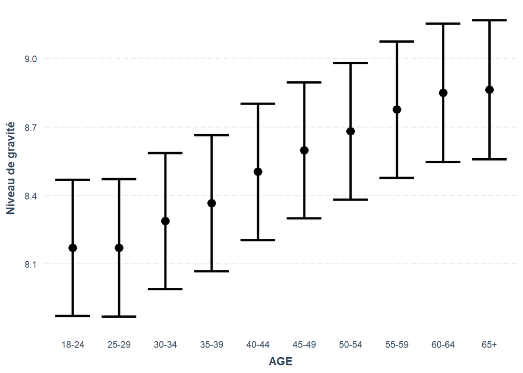

```r
effect_plot(m1, pred = AGE, interval = TRUE, plot.points = FALSE, y.label = "Niveau de gravité")
```

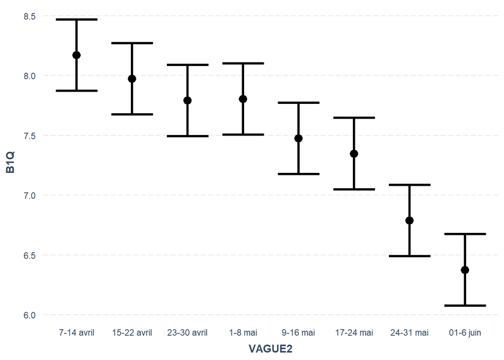

```r
effect_plot(m1, pred = VAGUE2, interval = TRUE, plot.points = FALSE)
```

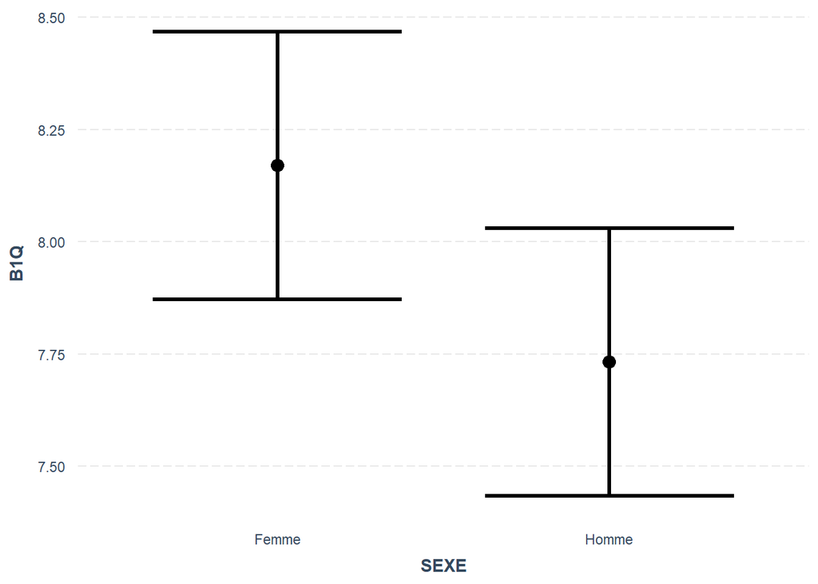

```r
effect_plot(m1, pred = SEXE, interval = TRUE, plot.points = FALSE)
```

## 5 - gestes barrières

### Description générale

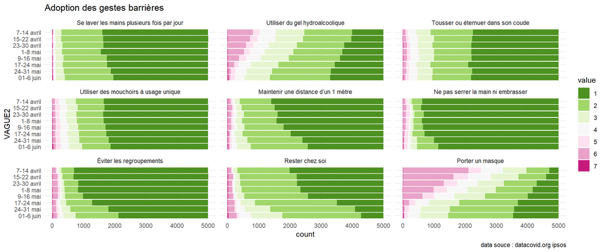

```r
foo1<-df  %>% select(VAGUE2,B2_0,B2_1,B2_2,B2_3,B2_4,B2_5,B2_6,B2_7,B2_8)
foo<-melt(foo1)
foo$value[foo$value>7]<-NA
foo$value[foo$value==0]<-NA
foo$value<-as.factor(foo$value)

Gestes=c("Se laver les mains plusieurs fois par jour",
                          "Utiliser du gel hydroalcoolique",
                          "Tousser ou éternuer dans son coude",
                          "Utiliser des mouchoirs à usage unique",
                          "Maintenir une distance d’un 1 mètre",
                          "Ne pas serrer la main ni embrasser",
                          "Éviter les regroupements",
                          "Rester chez soi",
                          "Porter un masque")
x<-as.factor(c("B2_0","B2_1","B2_2","B2_3","B2_4","B2_5","B2_6","B2_7","B2_8"))
names<-setNames(Gestes,x)
ggplot(foo,aes(x=VAGUE2,fill=value))+
  geom_bar(stat="count")+
  scale_fill_brewer(name="respect",labels=c("Tout le temps","Souvent","Parfois","Rarement","Jamais même si je peux","Jamais car je peux pas","Non Réponse"),palette = "Spectral")+
  scale_x_discrete(limits = rev)+scale_fill_brewer(palette = "PiYG",direction=-1)+
  facet_wrap(vars(variable),ncol=3,nrow=3,
             labeller = as_labeller(names))+  coord_flip() +  theme_minimal()+labs(title="Adoption des gestes barrières", caption = "data souce : datacovid.org ipsos")
```

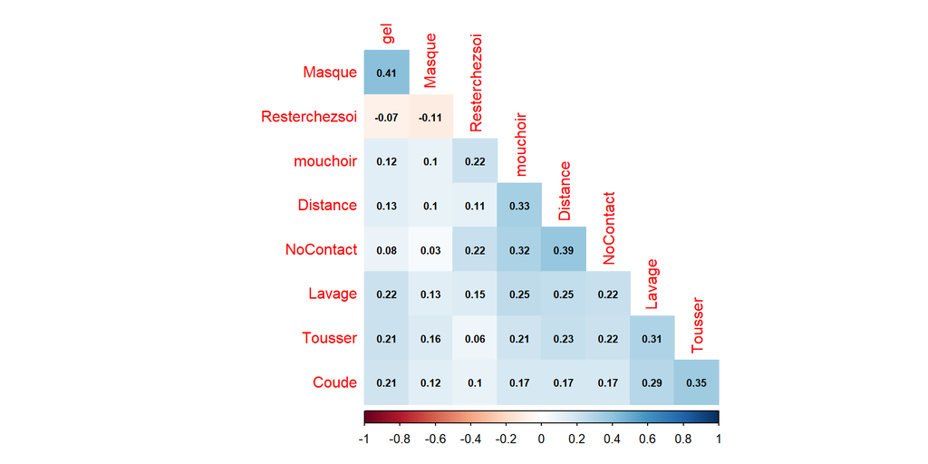

```r
foo1<-df  %>% select(B2_0,B2_1,B2_2,B2_3,B2_4,B2_5,B2_6,B2_7,B2_8) %>%
  rename(Lavage=B2_0 ,gel= B2_1,Tousser=B2_2,Coude=B2_3,mouchoir=B2_4,Distance=B2_5,NoContact=B2_6,Resterchezsoi=B2_7,Masque=B2_8)

m<-cor(foo1)
library(corrplot)
corrplot(m, method="color", label.cex=.7,number.cex = .7,type = "lower", addCoef.col = "black", order="hclust",diag=FALSE,addrect="4")
```

```r
fa<-fa(m,4)
fa
```

```
## Factor Analysis using method =  minres
## Call: fa(r = m, nfactors = 4)
## Standardized loadings (pattern matrix) based upon correlation matrix
##                 MR1   MR3   MR2   MR4   h2   u2 com
## Lavage         0.12  0.36  0.10  0.13 0.29 0.71 1.6
## gel           -0.02  0.05  0.68  0.01 0.48 0.52 1.0
## Tousser        0.07  0.59  0.00 -0.06 0.38 0.62 1.0
## Coude         -0.06  0.61  0.00  0.02 0.34 0.66 1.0
## mouchoir       0.39  0.03  0.10  0.21 0.30 0.70 1.7
## Distance       0.71  0.01 -0.01 -0.07 0.48 0.52 1.0
## NoContact      0.51  0.04 -0.02  0.15 0.35 0.65 1.2
## Resterchezsoi  0.00  0.00 -0.03  0.66 0.44 0.56 1.0
## Masque         0.02 -0.06  0.62 -0.04 0.37 0.63 1.0
##
##                        MR1  MR3  MR2  MR4
## SS loadings           1.02 0.93 0.89 0.58
## Proportion Var        0.11 0.10 0.10 0.06
## Cumulative Var        0.11 0.22 0.32 0.38
## Proportion Explained  0.30 0.27 0.26 0.17
## Cumulative Proportion 0.30 0.57 0.83 1.00
##
##  With factor correlations of
##      MR1  MR3   MR2   MR4
## MR1 1.00 0.51  0.24  0.34
## MR3 0.51 1.00  0.46  0.25
## MR2 0.24 0.46  1.00 -0.14
## MR4 0.34 0.25 -0.14  1.00
##
## Mean item complexity =  1.2
## Test of the hypothesis that 4 factors are sufficient.
##
## The degrees of freedom for the null model are  36  and the objective function was  1.17
## The degrees of freedom for the model are 6  and the objective function was  0
##
## The root mean square of the residuals (RMSR) is  0.01
## The df corrected root mean square of the residuals is  0.01
##
## Fit based upon off diagonal values = 1
## Measures of factor score adequacy
##                                                    MR1  MR3  MR2  MR4
## Correlation of (regression) scores with factors   0.81 0.80 0.80 0.72
## Multiple R square of scores with factors          0.66 0.64 0.63 0.52
## Minimum correlation of possible factor scores     0.32 0.28 0.27 0.04
```

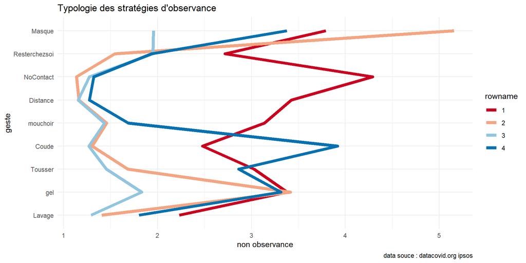

```r
group<-kmeans(foo1,centers=4)
typo <-as.data.frame(group$centers)%>% rownames_to_column() %>% melt()
typo$rowname<-as.factor(typo$rowname)
ggplot(typo,aes(x=variable,y=value,group=rowname))+geom_line(aes(color=rowname),size=2)+  coord_flip() +  theme_minimal()+labs(title="Typologie des stratégies d'observance", x="geste",y="non observance",caption = "data souce : datacovid.org ipsos")+scale_color_brewer(palette = "RdBu")
```

```r
hr <- hclust(dist(t(foo1),method="binary"), method = "complete")



dist(t(foo1))
```

```
##                 Lavage      gel  Tousser    Coude mouchoir Distance NoContact
## gel           375.9402
## Tousser       247.5783 371.3085
## Coude         247.9133 384.3150 270.5069
## mouchoir      224.9289 392.3646 281.8049 288.0868
## Distance      216.0833 414.9349 283.3284 288.8373 237.4384
## NoContact     234.9681 417.0671 291.3984 296.9192 248.6865 229.0982
## Resterchezsoi 270.1444 411.5179 318.0362 317.2523 279.2651 305.0672  291.3795
## Masque        489.8173 369.3183 467.3436 488.3749 491.0112 521.4259  521.2744
##               Resterchezsoi
## gel
## Tousser
## Coude
## mouchoir
## Distance
## NoContact
## Resterchezsoi
## Masque             498.0151
```

[figure not shown]

```r
plot(hr)
```

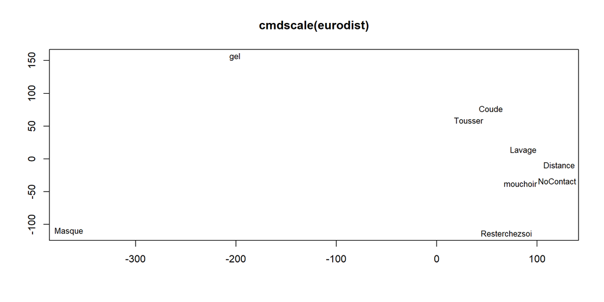

```r
loc <- cmdscale(dist(t(foo1)) )
plot(loc[,1], -loc[,2], type="n", xlab="", ylab="", main="cmdscale(eurodist)")
text(loc[,1], -loc[,2], rownames(loc), cex=0.8)
```

donc 4 stratégies (ensemble d’actions coordonnées dans un but)

- contrôle du corps, de soi.
- usage d’artefact, barrières et muselieres
- distance sociale,
- isolement ou retrait

## un modèle pour l’observance du masque

la perception de la gravité Le degré de santé mentale la proximité

un contrôle par les vagues d’enquêtes

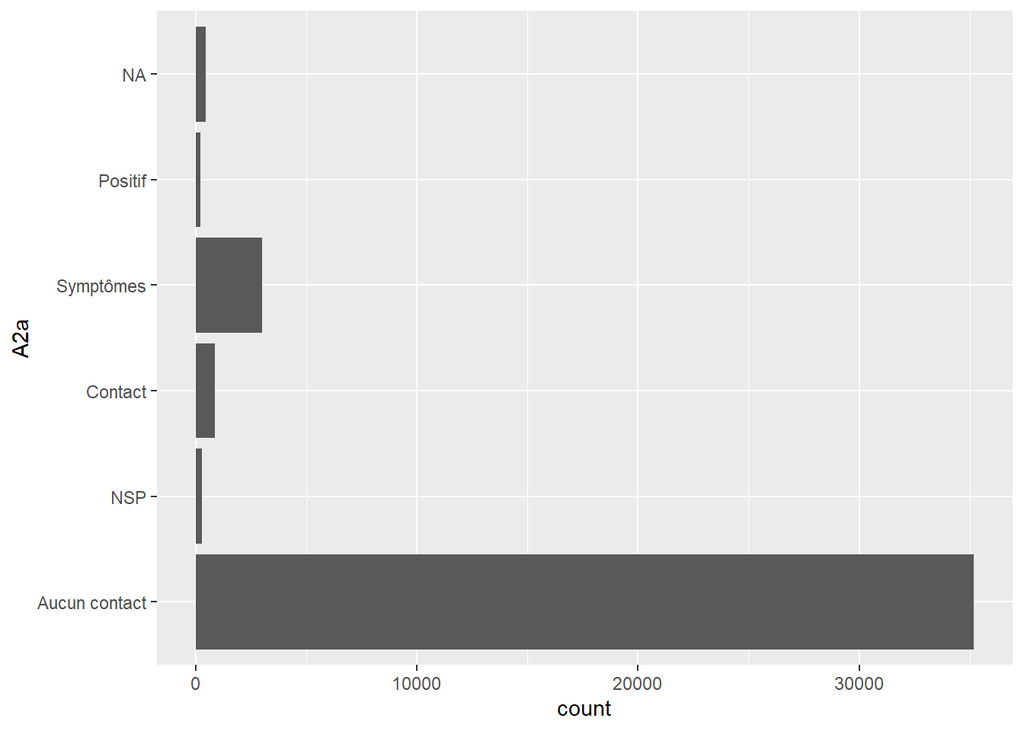

```r
df<-df %>%
  mutate(C5_0=ifelse(C5_0==5,NA,C5_0),C5_1=ifelse(C5_1==5,NA,C5_1),C5_2=ifelse(C5_2==5,NA,C5_2),C5_3=ifelse(C5_3==5,NA,C5_3))%>%
  mutate(SanteMentale=(C5_0+C5_1+C5_2+C5_3),Masque=7-B2_8)

df$A2a<-"zero"
df$A2a[df$A2==1]<- "Positif"
df$A2a[df$A2==2]<- "Symptômes"
df$A2a[df$A2==3]<- "Symptômes"
df$A2a[df$A2==4]<- "Contact"
df$A2a[df$A2==5]<- "Contact"
df$A2a[df$A2==6]<- "NSP"
df$A2a[df$A1==2]<- "Aucun contact"
df$A2a[is.na(df$A2a)]<-"NSP"

df$A2a<-factor(df$A2a,ordered = TRUE,levels = c("Aucun contact","NSP" ,"Contact","Symptômes", "Positif"))
ggplot(df,aes(x=A2a))+geom_bar()+coord_flip()
```

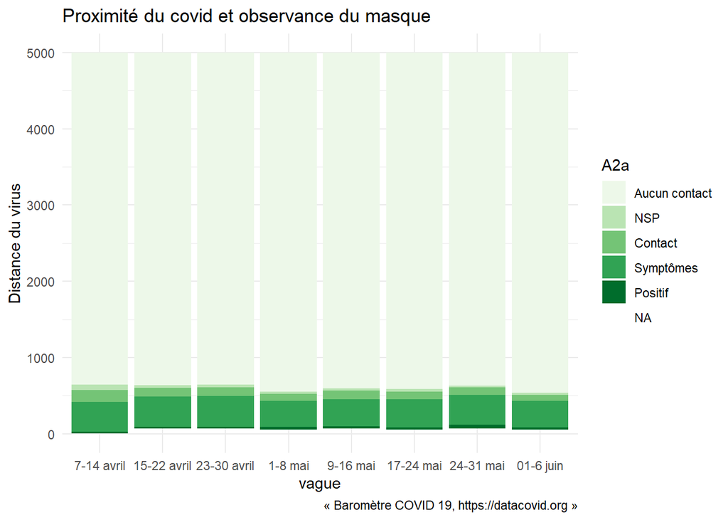

```r
g_a<-ggplot(df, aes(x=VAGUE2, y=Gravity)) +
  labs(title="Evolution de la perception de la gravité",x="Vague d'enquête", y = "Gravité perçue", caption="Source : data_covid")+
  geom_boxplot(aes(fill=VAGUE2),width=0.4,outlier.shape = NA)+
  theme_minimal()+ scale_fill_brewer(palette="Blues")  +
  theme(legend.position = "none")

g_b<-ggplot(df, aes(x=VAGUE2, y=SanteMentale)) +
  labs(title="Evolution de la bonne Santé Mentale",x="Vague d'enquête", y = "Santé mentale(bonne)")+
  geom_boxplot(aes(fill=VAGUE2),width=0.4,outlier.shape = NA)+
  theme_minimal()+ scale_fill_brewer(palette="Greens") +
  theme(legend.position = "none")

g0<-ggplot(df,aes(x=VAGUE2, group=A2a))+geom_bar(aes(fill=A2a), stat = "count")+  theme_minimal()+ labs(title = "Proximité du covid et observance du masque",x ="vague",y="Distance du virus",caption = "« Baromètre COVID 19, https://datacovid.org »")+ scale_fill_brewer(palette="Greens")

g0
```

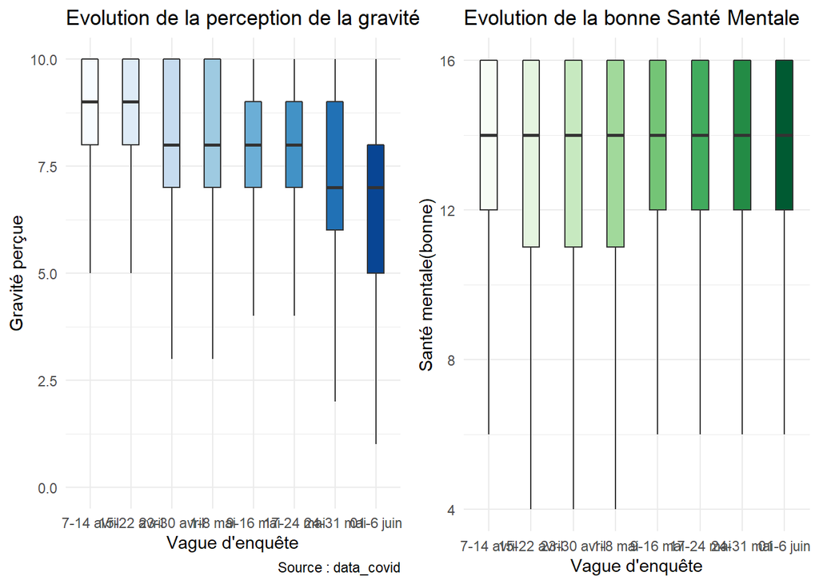

```r
library(gridExtra)
grid.arrange(g_a,g_b,ncol=2)
```

Ces trois variables rerésente en fait 3 théories

- la gravité est celle du risque perçu qui conduit de manière rationnelle les individus à la réduire en adoptant la norme pour réduire l’incertitude
- le degré de bonne santé mentale qui renforce l’auto efficacité, la confiance en soi, et conduit à minimiser les risques.
- le degre de proximité de la maladie qui reflète la théorie des niveaux de construit.

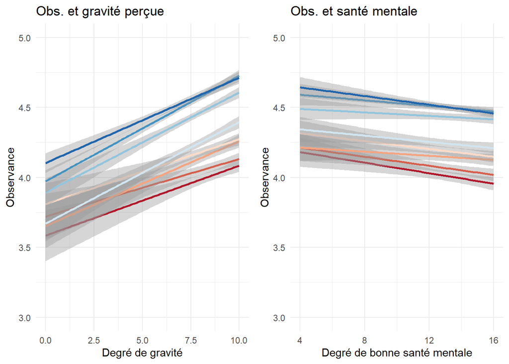

```r
g_c<-ggplot(df,aes(x= Gravity,y=Masque,group=VAGUE2))+geom_smooth(aes(color=VAGUE2),method=lm)+  theme_minimal()+labs(title="Obs. et gravité perçue", x="Degré de gravité",y="Observance")+scale_color_brewer(palette = "RdBu")+
  theme(legend.position = "none") +ylim(3,5)

g_d<-ggplot(df,aes(x= SanteMentale,y=Masque,group=VAGUE2))+geom_smooth(aes(color=VAGUE2),method=lm)+labs(title="Obs. et santé mentale", x="Degré de bonne santé mentale",y="Observance")+scale_color_brewer(palette = "RdBu")+  theme_minimal()+
  theme(legend.position = "none")  +ylim(3,5)
grid.arrange(g_c,g_d,ncol=2)
```

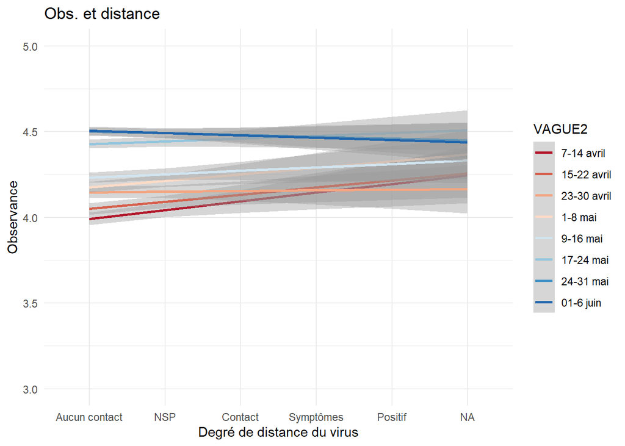

```r
g_e<-ggplot(df,aes(x= A2a,y=Masque,group=VAGUE2))+geom_smooth(aes(color=VAGUE2),method=lm)+labs(title="Obs. et distance", x="Degré de distance du virus",y="Observance")+scale_color_brewer(palette = "RdBu")+  theme_minimal()   +ylim(3,5)
g_e
```

### Modélisation

```r
df$VAGUE2<-factor(df$VAGUE2, ordered = FALSE ) #beaucause before ordered
df$A2a<-factor(df$A2a, ordered = FALSE )
df$AGE<-factor(df$AGE, ordered = FALSE )

fit1<-lm(Masque~Gravity+SanteMentale+VAGUE2,data=df)
summ(fit1)
```

| Observations | 39778 (223 missing obs. deleted) |
| --- | --- |
| Dependent variable | Masque |
| Type | OLS linear regression |

| F(9,39768) | 1266.02 |
| --- | --- |
| R² | 0.22 |
| Adj. R² | 0.22 |

|  | Est. | S.E. | t val. | p |
| --- | --- | --- | --- | --- |
| (Intercept) | 1.68 | 0.05 | 31.78 | 0.00 |
| Gravity | 0.13 | 0.00 | 32.52 | 0.00 |
| SanteMentale | -0.01 | 0.00 | -2.92 | 0.00 |
| VAGUE215-22 avril | 0.35 | 0.03 | 11.47 | 0.00 |
| VAGUE223-30 avril | 0.74 | 0.03 | 24.39 | 0.00 |
| VAGUE21-8 mai | 1.02 | 0.03 | 33.43 | 0.00 |
| VAGUE29-16 mai | 1.40 | 0.03 | 45.79 | 0.00 |
| VAGUE217-24 mai | 2.02 | 0.03 | 65.78 | 0.00 |
| VAGUE224-31 mai | 2.30 | 0.03 | 74.32 | 0.00 |
| VAGUE201-6 juin | 2.39 | 0.03 | 76.30 | 0.00 |

Standard errors: OLS

```r
fit2<-lm(Masque~Gravity*SanteMentale+VAGUE2,data=df)
summ(fit2)
```

| Observations | 39778 (223 missing obs. deleted) |
| --- | --- |
| Dependent variable | Masque |
| Type | OLS linear regression |

| F(10,39767) | 1139.93 |
| --- | --- |
| R² | 0.22 |
| Adj. R² | 0.22 |

|  | Est. | S.E. | t val. | p |
| --- | --- | --- | --- | --- |
| (Intercept) | 1.93 | 0.14 | 14.31 | 0.00 |
| Gravity | 0.10 | 0.02 | 6.14 | 0.00 |
| SanteMentale | -0.03 | 0.01 | -2.71 | 0.01 |
| VAGUE215-22 avril | 0.35 | 0.03 | 11.47 | 0.00 |
| VAGUE223-30 avril | 0.74 | 0.03 | 24.40 | 0.00 |
| VAGUE21-8 mai | 1.02 | 0.03 | 33.41 | 0.00 |
| VAGUE29-16 mai | 1.40 | 0.03 | 45.80 | 0.00 |
| VAGUE217-24 mai | 2.02 | 0.03 | 65.79 | 0.00 |
| VAGUE224-31 mai | 2.30 | 0.03 | 74.35 | 0.00 |
| VAGUE201-6 juin | 2.39 | 0.03 | 76.33 | 0.00 |
| Gravity:SanteMentale | 0.00 | 0.00 | 2.05 | 0.04 |

Standard errors: OLS

```r
fit3<-lm(Masque~Gravity*SanteMentale+A2a+VAGUE2,data=df)
summ(fit3)
```

| Observations | 39339 (662 missing obs. deleted) |
| --- | --- |
| Dependent variable | Masque |
| Type | OLS linear regression |

| F(14,39324) | 819.44 |
| --- | --- |
| R² | 0.23 |
| Adj. R² | 0.23 |

|  | Est. | S.E. | t val. | p |
| --- | --- | --- | --- | --- |
| (Intercept) | 1.82 | 0.14 | 13.37 | 0.00 |
| Gravity | 0.10 | 0.02 | 6.34 | 0.00 |
| SanteMentale | -0.02 | 0.01 | -2.15 | 0.03 |
| A2aNSP | 0.03 | 0.09 | 0.34 | 0.73 |
| A2aContact | 0.23 | 0.05 | 4.31 | 0.00 |
| A2aSymptômes | 0.16 | 0.03 | 5.33 | 0.00 |
| A2aPositif | 0.72 | 0.10 | 7.21 | 0.00 |
| VAGUE215-22 avril | 0.35 | 0.03 | 11.51 | 0.00 |
| VAGUE223-30 avril | 0.74 | 0.03 | 24.33 | 0.00 |
| VAGUE21-8 mai | 1.02 | 0.03 | 33.48 | 0.00 |
| VAGUE29-16 mai | 1.40 | 0.03 | 45.80 | 0.00 |
| VAGUE217-24 mai | 2.02 | 0.03 | 65.83 | 0.00 |
| VAGUE224-31 mai | 2.31 | 0.03 | 74.33 | 0.00 |
| VAGUE201-6 juin | 2.40 | 0.03 | 76.44 | 0.00 |
| Gravity:SanteMentale | 0.00 | 0.00 | 1.92 | 0.06 |

Standard errors: OLS

```r
fit4<-lm(Masque~Gravity*SanteMentale+A2a+VAGUE2+AGE+SEXE,data=df)
summ(fit4)
```

| Observations | 39339 (662 missing obs. deleted) |
| --- | --- |
| Dependent variable | Masque |
| Type | OLS linear regression |

| F(24,39314) | 490.32 |
| --- | --- |
| R² | 0.23 |
| Adj. R² | 0.23 |

|  | Est. | S.E. | t val. | p |
| --- | --- | --- | --- | --- |
| (Intercept) | 1.89 | 0.14 | 13.75 | 0.00 |
| Gravity | 0.09 | 0.02 | 5.57 | 0.00 |
| SanteMentale | -0.02 | 0.01 | -2.40 | 0.02 |
| A2aNSP | 0.06 | 0.09 | 0.66 | 0.51 |
| A2aContact | 0.27 | 0.05 | 5.23 | 0.00 |
| A2aSymptômes | 0.18 | 0.03 | 6.20 | 0.00 |
| A2aPositif | 0.79 | 0.10 | 7.92 | 0.00 |
| VAGUE215-22 avril | 0.34 | 0.03 | 11.33 | 0.00 |
| VAGUE223-30 avril | 0.74 | 0.03 | 24.22 | 0.00 |
| VAGUE21-8 mai | 1.01 | 0.03 | 33.18 | 0.00 |
| VAGUE29-16 mai | 1.39 | 0.03 | 45.43 | 0.00 |
| VAGUE217-24 mai | 2.01 | 0.03 | 65.74 | 0.00 |
| VAGUE224-31 mai | 2.29 | 0.03 | 73.93 | 0.00 |
| VAGUE201-6 juin | 2.37 | 0.03 | 75.77 | 0.00 |
| AGE25-29 | 0.08 | 0.04 | 1.93 | 0.05 |
| AGE30-34 | 0.07 | 0.04 | 1.90 | 0.06 |
| AGE35-39 | 0.05 | 0.04 | 1.47 | 0.14 |
| AGE40-44 | 0.04 | 0.04 | 1.20 | 0.23 |
| AGE45-49 | 0.10 | 0.04 | 2.70 | 0.01 |
| AGE50-54 | 0.08 | 0.04 | 2.15 | 0.03 |
| AGE55-59 | 0.13 | 0.04 | 3.40 | 0.00 |
| AGE60-64 | 0.17 | 0.04 | 4.57 | 0.00 |
| AGE65+ | 0.28 | 0.03 | 8.98 | 0.00 |
| SEXEHomme | -0.17 | 0.02 | -10.72 | 0.00 |
| Gravity:SanteMentale | 0.00 | 0.00 | 2.08 | 0.04 |

Standard errors: OLS

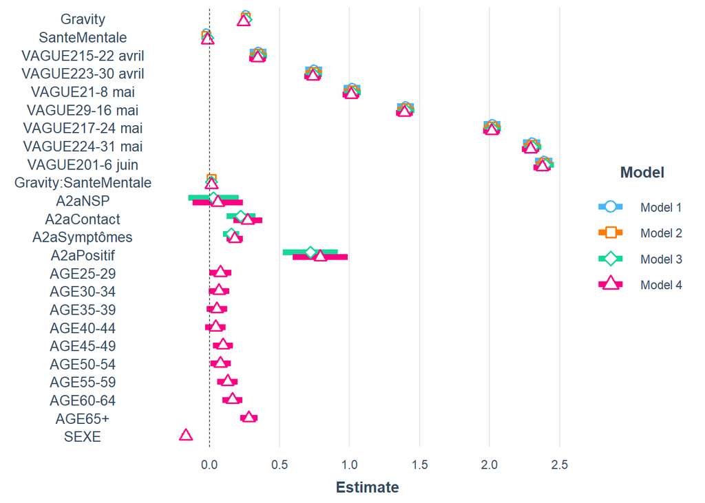

```r
plot_summs(fit1,fit2,fit3,fit4,scale = TRUE, plot.distributions = FALSE, inner_ci_level = .95)
```

```r
export_summs(fit1,fit2,fit3,fit4, scale = FALSE,digits=3,model.names = c("Gravité perçue(lm)","Avec contrôle\n vague d'enquête (lm)","Avec contrôle \ndes variables de position sociale (lm)", "et contrôle des CSP"))
```

[output not shown]

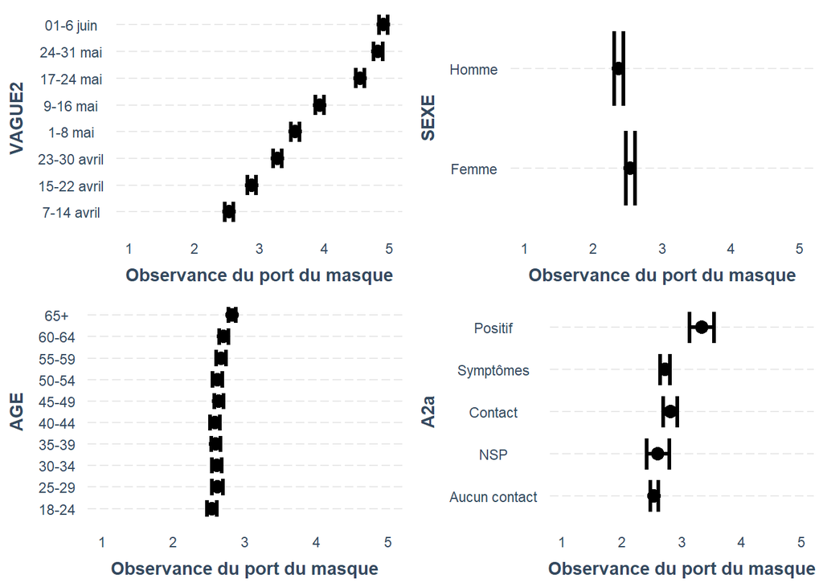

```r
G1<-effect_plot(fit4,VAGUE2,int.type = "confidence")+labs(y ="Observance du port du masque")+ylim(1,5)+coord_flip()
G2<-effect_plot(fit4,SEXE,int.type = "confidence")+labs(y ="Observance du port du masque")+ylim(1,5)+coord_flip()
G3<-effect_plot(fit4,AGE,int.type = "confidence")+ylim(1,5)+coord_flip()+labs(y ="Observance du port du masque")
G4<-effect_plot(fit4,A2a,int.type = "confidence")+ylim(1,5)+coord_flip()+labs(y ="Observance du port du masque")
grid.arrange(G1,G2,G3,G4,ncol=2)
```

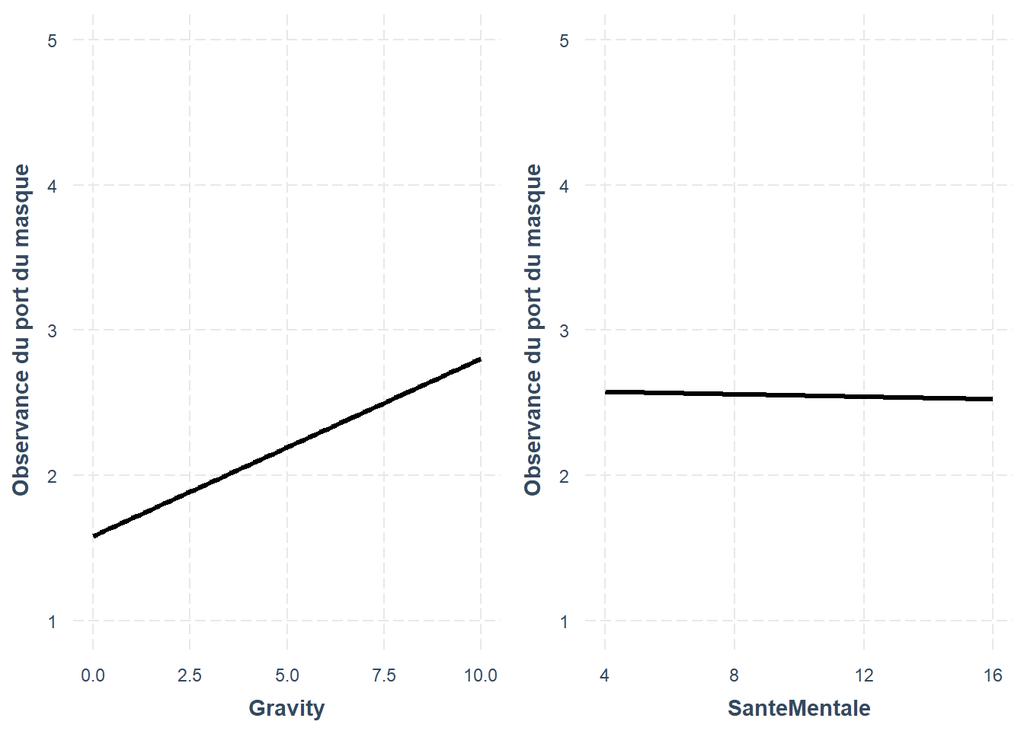

```r
G5<-effect_plot(fit4,Gravity,int.type = "confidence")+ylim(1,5)+labs(y ="Observance du port du masque")
G6<-effect_plot(fit4,SanteMentale,int.type = "confidence")+ylim(1,5)+labs(y ="Observance du port du masque")
grid.arrange(G5,G6,ncol=2)
```

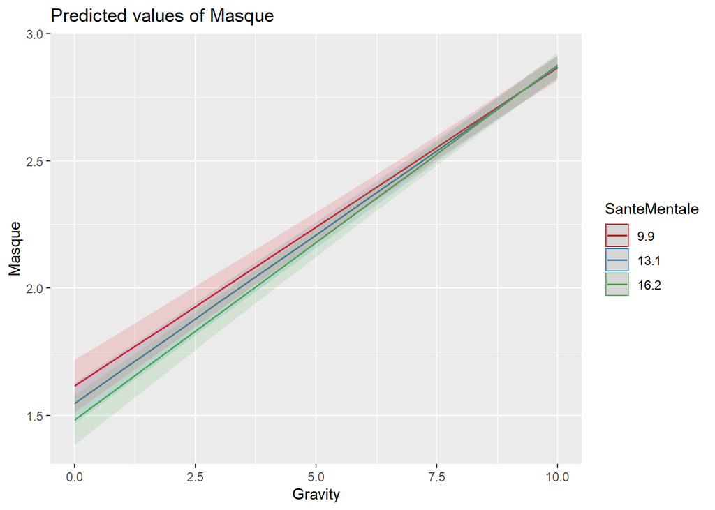

```r
plot_model(fit3, type = "pred", terms = c("Gravity", "SanteMentale"))
```

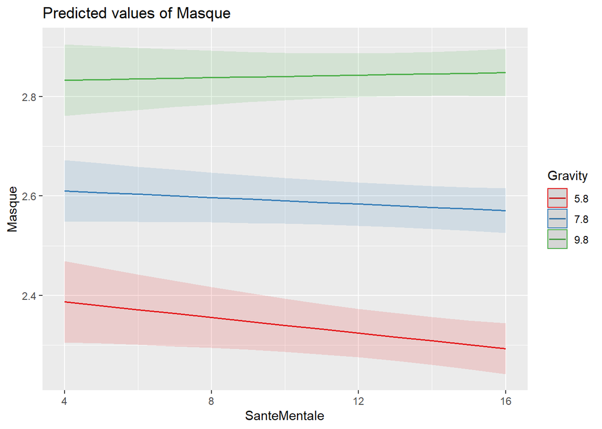

```r
plot_model(fit3, type = "pred", terms = c("SanteMentale", "Gravity"))
```